# Exercise 4.1.7

W. Mangrobang

##### Run CHUNK 1 to load MEPS data.

```r
#CHUNK 1
library(miceadds) #To load Rdata
load.Rdata('/Users/Werlindo/Dropbox/PACP/data/H171.Rdata','meps')

#Take a look
head(meps[,1:10])
```

|  | DUID | PID | DUPERSID | PANEL | FAMID31 | FAMID42 | FAMID53 | FAMID14 | FAMIDYR | CPSFAMID |
| --- | --- | --- | --- | --- | --- | --- | --- | --- | --- | --- |
| 1 | 40001 | 101 | 40001101 | 18 | A | A | A | A | A | A |
| 2 | 40001 | 102 | 40001102 | 18 | A | A | A | A | A | A |
| 3 | 40001 | 103 | 40001103 | 18 | A | A | A | A | A | A |
| 4 | 40001 | 104 | 40001104 | 18 | A | A | A | A | A | A |
| 5 | 40002 | 101 | 40002101 | 18 | A | A | A | A | A | A |
| 6 | 40004 | 101 | 40004101 | 18 | A | A | A | A | A | A |

```r
tail(meps[,1:10])
```

|  | DUID | PID | DUPERSID | PANEL | FAMID31 | FAMID42 | FAMID53 | FAMID14 | FAMIDYR | CPSFAMID |
| --- | --- | --- | --- | --- | --- | --- | --- | --- | --- | --- |
| 34870 | 69664 | 102 | 69664102 | 19 | A | A | A | A | A | A |
| 34871 | 69665 | 102 | 69665102 | 19 | A | A | A | A | A | A |
| 34872 | 69665 | 103 | 69665103 | 19 | A | A | A | A | A | A |
| 34873 | 69665 | 104 | 69665104 | 19 | A | A | A | A | A | A |
| 34874 | 69667 | 101 | 69667101 | 19 | A | A | A | A | A | A |
| 34875 | 69667 | 102 | 69667102 | 19 | B | B | B | B | B | B |

Seems OK. Need to pick out subset of data to explore.

…

After looking over the documentation, I picked out a subset of variables to practice with.

I saved it as a csv.

##### Run CHUNK 2 to create a data subset.

```r
#Get list of selected fields
meps.sel <- read.csv('/users/werlindo/dropbox/pacp/4 Data Exploration/4.1 univariate eda/ex4_1_meps_selected.csv',stringsAsFactors = FALSE)
meps.sel
```

| Name |
| --- |
| AGE14X |
| PID |
| SEX |
| TOTEXP14 |
| TOTMCD14 |
| TOTMCR14 |
| TOTOFD14 |
| TOTOPR14 |
| TOTOPU14 |
| TOTOSR14 |

[output cut: 10 more lines]

```r
#Change to vector
meps.sel <- meps.sel$Name

#Make subset
meps.sub <- meps[,meps.sel]
head(meps.sub)
```

|  | AGE14X | PID | SEX | TOTEXP14 | TOTMCD14 | TOTMCR14 | TOTOFD14 | TOTOPR14 | TOTOPU14 | TOTOSR14 | TOTOTH14 | TOTPRV14 | TOTPTR14 | TOTSLF14 | TOTSTL14 | TOTTCH14 | TOTTRI14 | TOTVA14 | TOTWCP14 | REGION14 |
| --- | --- | --- | --- | --- | --- | --- | --- | --- | --- | --- | --- | --- | --- | --- | --- | --- | --- | --- | --- | --- |
| 1 | 36 | 101 | 1 | 1518 | 0 | 0 | 0 | 0 | 0 | 0 | 0 | 1353 | 1353 | 165 | 0 | 1426 | 0 | 0 | 0 | 3 |
| 2 | 36 | 102 | 2 | 1234 | 0 | 0 | 0 | 0 | 0 | 0 | 0 | 1082 | 1082 | 152 | 0 | 1761 | 0 | 0 | 0 | 3 |
| 3 | 15 | 103 | 2 | 671 | 0 | 0 | 0 | 0 | 0 | 0 | 0 | 536 | 536 | 135 | 0 | 919 | 0 | 0 | 0 | 3 |
| 4 | 8 | 104 | 1 | 252 | 0 | 0 | 0 | 0 | 0 | 0 | 0 | 163 | 163 | 89 | 0 | 325 | 0 | 0 | 0 | 3 |
| 5 | 85 | 101 | 2 | 10904 | 0 | 9279 | 0 | 0 | 0 | 0 | 0 | 1622 | 1622 | 2 | 0 | 45544 | 0 | 0 | 0 | 1 |
| 6 | 34 | 101 | 1 | 0 | 0 | 0 | 0 | 0 | 0 | 0 | 0 | 0 | 0 | 0 | 0 | 0 | 0 | 0 | 0 | 3 |

```r
#Do a little data scrubbing
meps.sub$PID <- as.factor(meps.sub$PID)
meps.sub$SEX <- as.factor(meps.sub$SEX)
meps.sub$REGION14 <- as.factor(meps.sub$REGION14)
```

##### Run CHUNK 3 to determine the sample means and variances of each variable.

```r
#CHUNK 2
data.frame(mean = sapply(meps.sub, mean),
           var = sapply(meps.sub, var))
```

|  | mean | var |
| --- | --- | --- |
| AGE14X | 34.713233 | 5.074582e+02 |
| PID | NA | 1.298803e+01 |
| SEX | NA | 2.495203e-01 |
| TOTEXP14 | 3915.539670 | 1.654367e+08 |
| TOTMCD14 | 707.685591 | 1.816171e+07 |
| TOTMCR14 | 1120.411154 | 4.834257e+07 |
| TOTOFD14 | 6.575283 | 5.725899e+04 |
| TOTOPR14 | 81.153491 | 3.093059e+06 |
| TOTOPU14 | 20.603384 | 7.177483e+05 |
| TOTOSR14 | 67.960344 | 2.378015e+06 |

[output cut: 10 more lines]

As expected PID and SEX should be NA because me made them factors.

##### Run CHUNK 4 to plot some variables as scatterplots.

Plot vs dollars.Going to log-transform the dollars for scale and remove zero dollars.

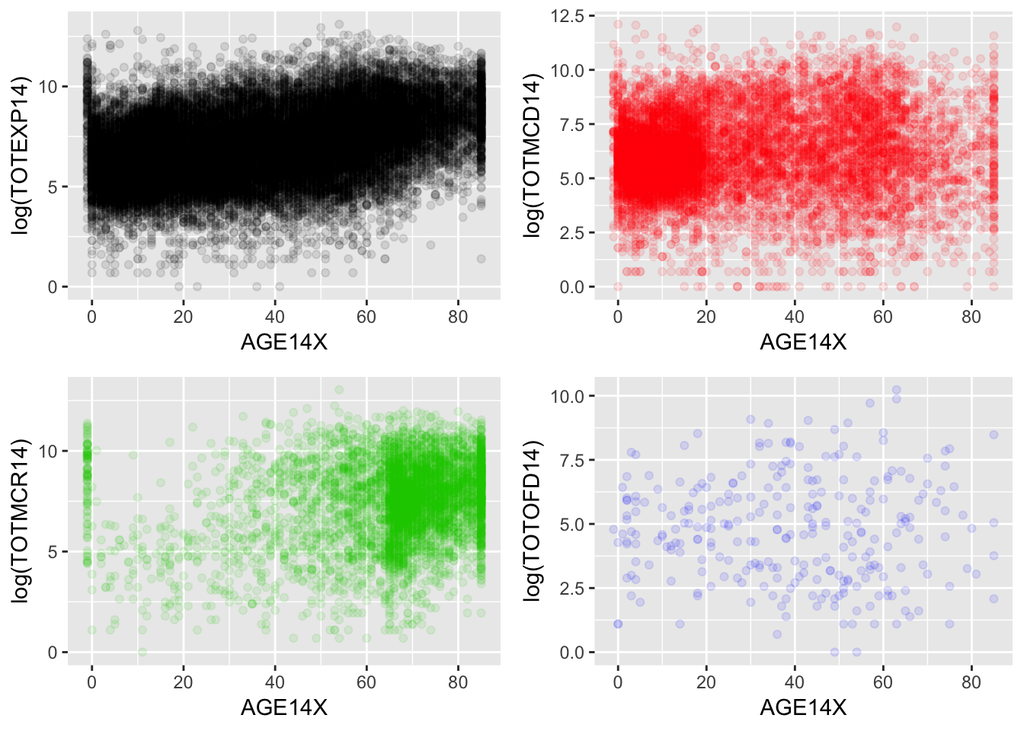

```r
#CHUNK 4
library(ggplot2)
library(gridExtra)
p1 <- ggplot(data = meps.sub[meps.sub$TOTEXP14!=0,], aes(x = AGE14X, y = log(TOTEXP14) )) +
       geom_point(color = 1,alpha = 0.1)
p2 <- ggplot(data = meps.sub[meps.sub$TOTMCD14!=0,], aes(x = AGE14X, y = log(TOTMCD14) )) +
       geom_point(color = 2,alpha = 0.1)
p3 <- ggplot(data = meps.sub[meps.sub$TOTMCR14!=0,], aes(x = AGE14X, y = log(TOTMCR14) )) +
       geom_point(color = 3,alpha = 0.1)
p4 <- ggplot(data = meps.sub[meps.sub$TOTOFD14!=0,], aes(x = AGE14X, y = log(TOTOFD14) )) +
       geom_point(color = 4,alpha = 0.1) #+ ylim(2,14)
grid.arrange(p1,p2,p3,p4,ncol=2)
```

##### Run CHUNK 5 to see the output from the summary function.

```r
#CHUNK 5
summary(meps.sub)
```

```
##      AGE14X           PID        SEX          TOTEXP14
##  Min.   :-1.00   101    :11947   1:16668   Min.   :     0
##  1st Qu.:15.00   102    : 8747   2:18207   1st Qu.:    78
##  Median :33.00   103    : 5670             Median :   571
##  Mean   :34.71   104    : 3858             Mean   :  3916
##  3rd Qu.:52.00   105    : 2003             3rd Qu.:  2676
##  Max.   :85.00   106    :  891             Max.   :491858
##                  (Other): 1759
##     TOTMCD14           TOTMCR14         TOTOFD14
##  Min.   :     0.0   Min.   :     0   Min.   :    0.000
##  1st Qu.:     0.0   1st Qu.:     0   1st Qu.:    0.000
##  Median :     0.0   Median :     0   Median :    0.000
##  Mean   :   707.7   Mean   :  1120   Mean   :    6.575
##  3rd Qu.:    78.0   3rd Qu.:     0   3rd Qu.:    0.000
##  Max.   :180714.0   Max.   :459705   Max.   :27835.000
##
##     TOTOPR14            TOTOPU14           TOTOSR14
##  Min.   :     0.00   Min.   :     0.0   Min.   :     0.00
##  1st Qu.:     0.00   1st Qu.:     0.0   1st Qu.:     0.00
##  Median :     0.00   Median :     0.0   Median :     0.00
##  Mean   :    81.15   Mean   :    20.6   Mean   :    67.96
##  3rd Qu.:     0.00   3rd Qu.:     0.0   3rd Qu.:     0.00
##  Max.   :203569.00   Max.   :121643.0   Max.   :176007.00
##
##     TOTOTH14           TOTPRV14         TOTPTR14         TOTSLF14
##  Min.   :     0.0   Min.   :     0   Min.   :     0   Min.   :    0.0
##  1st Qu.:     0.0   1st Qu.:     0   1st Qu.:     0   1st Qu.:    0.0
##  Median :     0.0   Median :     0   Median :     0   Median :   38.0
##  Mean   :   227.1   Mean   :  1293   Mean   :  1320   Mean   :  416.6
##  3rd Qu.:     0.0   3rd Qu.:   428   3rd Qu.:   456   3rd Qu.:  326.0
##  Max.   :235510.0   Max.   :414267   Max.   :414267   Max.   :72095.0
##
##     TOTSTL14           TOTTCH14          TOTTRI14
##  Min.   :    0.00   Min.   :      0   Min.   :    0.00
##  1st Qu.:    0.00   1st Qu.:    100   1st Qu.:    0.00
##  Median :    0.00   Median :    756   Median :    0.00
##  Mean   :   50.82   Mean   :   8673   Mean   :   27.19
##  3rd Qu.:    0.00   3rd Qu.:   3740   3rd Qu.:    0.00
##  Max.   :46677.00   Max.   :2018306   Max.   :26008.00
##
##     TOTVA14             TOTWCP14        REGION14
##  Min.   :     0.00   Min.   :    0.00   -1:  209
##  1st Qu.:     0.00   1st Qu.:    0.00   1 : 5292
##  Median :     0.00   Median :    0.00   2 : 6299
##  Mean   :    88.43   Mean   :   35.42   3 :13135
##  3rd Qu.:     0.00   3rd Qu.:    0.00   4 : 9940
##  Max.   :245257.00   Max.   :73092.00
##
```

Note most of the dollar variables (starting with TOT-) have medians of 0. Not surprising because these are healthcare expenditures. As a broad generality, most people have little.

##### Run CHUNK 6 to calculate a variety of statistics. I’ll use age as the numeric variable.

```r
#CHUNK 6
stats.central <- data.frame(mean = mean(meps.sub$AGE14X),
                            median = median(meps.sub$AGE14X),
                            percentile5 = quantile(meps.sub$AGE14X, 0.05),
                            percentile25 = quantile(meps.sub$AGE14X, 0.25),
                            percentile50 = quantile(meps.sub$AGE14X, 0.50),
                            percentile75 = quantile(meps.sub$AGE14X, 0.75),
                            percentile95 = quantile(meps.sub$AGE14X, 0.95),
                            max = max(meps.sub$AGE14X),
                            min = min(meps.sub$AGE14X),
                            row.names = c("AGE14X"))
stats.central
```

|  | mean | median | percentile5 | percentile25 | percentile50 | percentile75 | percentile95 | max | min |
| --- | --- | --- | --- | --- | --- | --- | --- | --- | --- |
| AGE14X | 34.71323 | 33 | 3 | 15 | 33 | 52 | 74 | 85 | -1 |

##### Run CHUNK 7 to calculate some measures of spread.

```r
#CHUNK 7
library(e1071)
stats.spread <- data.frame(variance = var(meps.sub$AGE14X),
                           standardDev = sd(meps.sub$AGE14X),
                           iqr = IQR(meps.sub$AGE14X),
                           skew = skewness(meps.sub$AGE14X),
                           kurtosis = kurtosis(meps.sub$AGE14X),
                           row.names = c("AGE14X"))
stats.spread
```

|  | variance | standardDev | iqr | skew | kurtosis |
| --- | --- | --- | --- | --- | --- |
| AGE14X | 507.4582 | 22.52683 | 37 | 0.301357 | -0.9168103 |

##### Run CHUNK 8 to make a histogram of age.

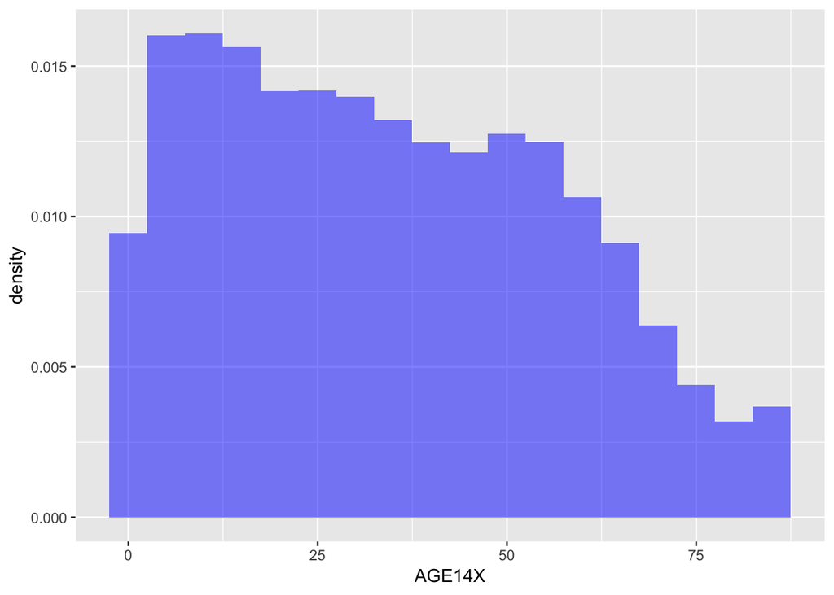

```r
#CHUNK 8
p2 <- ggplot(data = meps.sub, aes(AGE14X, ..density..)) +
       geom_histogram(binwidth = 5, fill = "blue", alpha = 0.5)
p2
```

##### Run CHUNK 9 to see different bin widths.

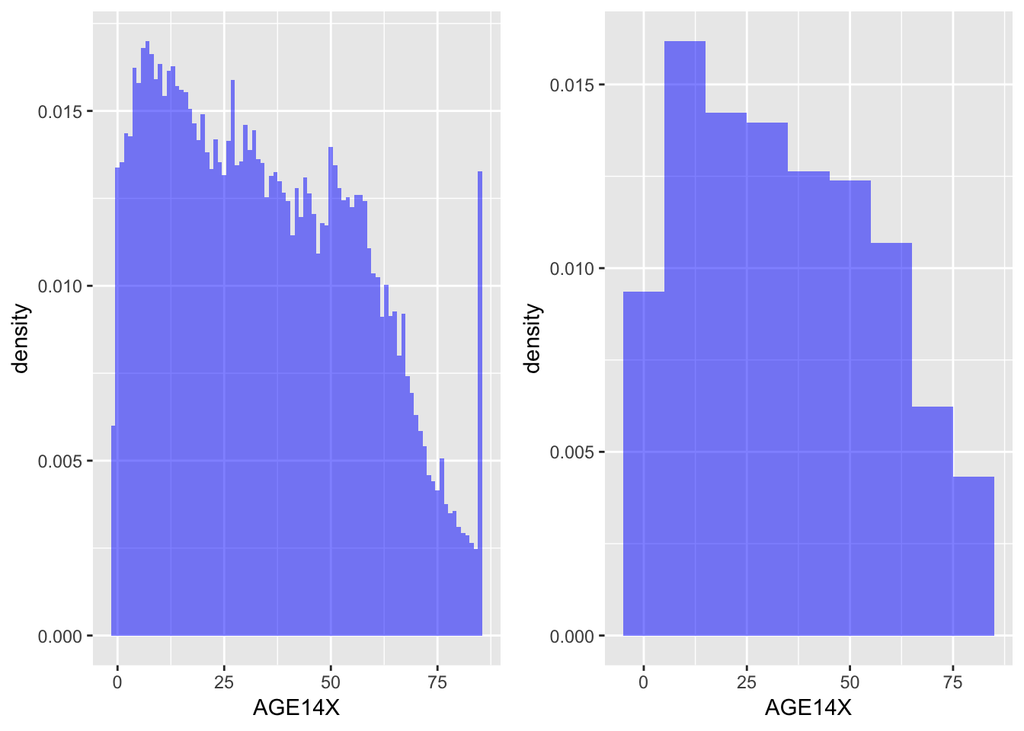

```r
#CHUNK 9
p1 <- ggplot(data = meps.sub, aes(AGE14X, ..density..)) +
       geom_histogram(binwidth = 1, fill = "blue", alpha = 0.5)
p2 <- ggplot(data = meps.sub, aes(AGE14X, ..density..)) +
       geom_histogram(binwidth = 10, fill = "blue", alpha = 0.5)
grid.arrange(p1,p2,ncol=2)
```

There appears to be a noticeable spike at the top of the age histogram. Worth investigating in the future.

##### Run CHUNK 10 to make histograms of log(TOTEXP14) .

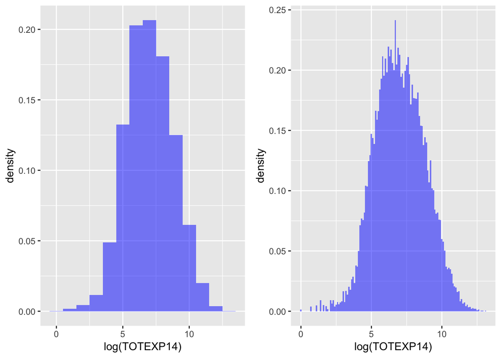

```r
#CHUNK 10
p1 <- ggplot(data = meps.sub, aes(log(TOTEXP14) , ..density..)) +
       geom_histogram(binwidth = 1, fill = "blue", alpha = 0.5)
p1.w <- ggplot(data = meps.sub, aes(log(TOTEXP14) , ..density..)) +
       geom_histogram(binwidth = .1, fill = "blue", alpha = 0.5)


grid.arrange(p1,p1.w, nrow = 1, ncol=2)
```

```r
?grid.arrange
```

Looks roughly normal after log transformation.

##### Run CHUNK 11 to split the variables by region.

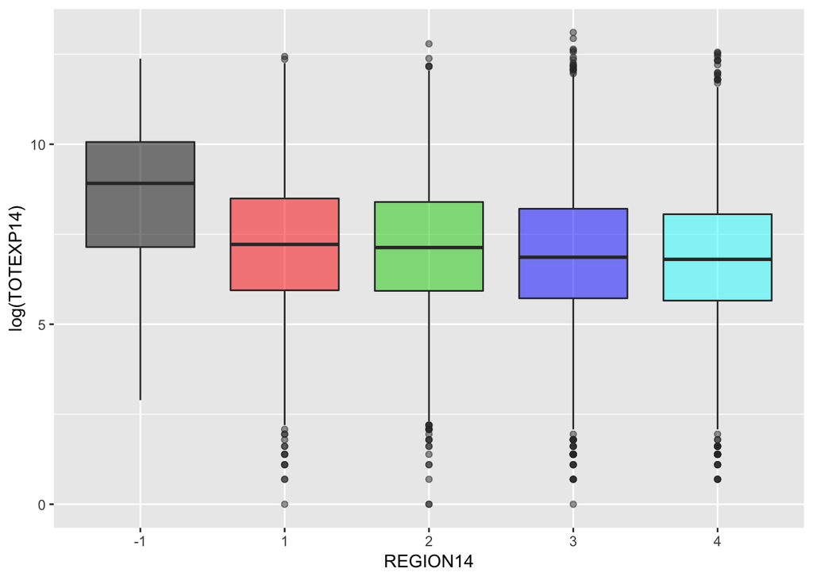

```r
#CHUNK 11
p1 <- ggplot(data = meps.sub, aes(x = REGION14, y = log(TOTEXP14))) +
        geom_boxplot(fill = c(1:5), alpha = 0.5)
p4 <- ggplot(data = meps.sub, aes(x = "attage", y = log(TOTEXP14))) +
        geom_boxplot(alpha = 0.5)
p1
```

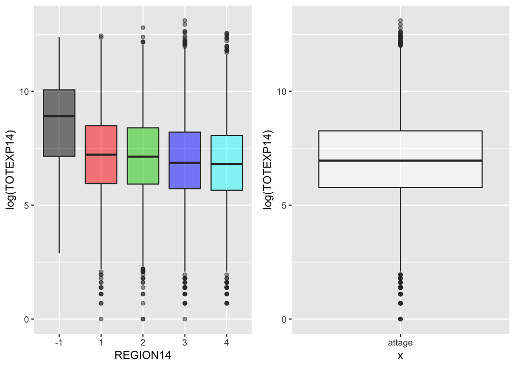

```r
#
grid.arrange(p1,p4,ncol=2)
```

Looks like there may be differences in expenditures by region.

##### Run CHUNK 12 to make a frequency table.

```r
#CHUNK 12
table(meps.sub$REGION14)
```

```
##
##    -1     1     2     3     4
##   209  5292  6299 13135  9940
```

```r
table(meps.sub$REGION14) / nrow(meps.sub)
```

```
##
##          -1           1           2           3           4
## 0.005992832 0.151741935 0.180616487 0.376630824 0.285017921
```

##### Run CHUNK 13 to turn the frequency table into a bar chart.

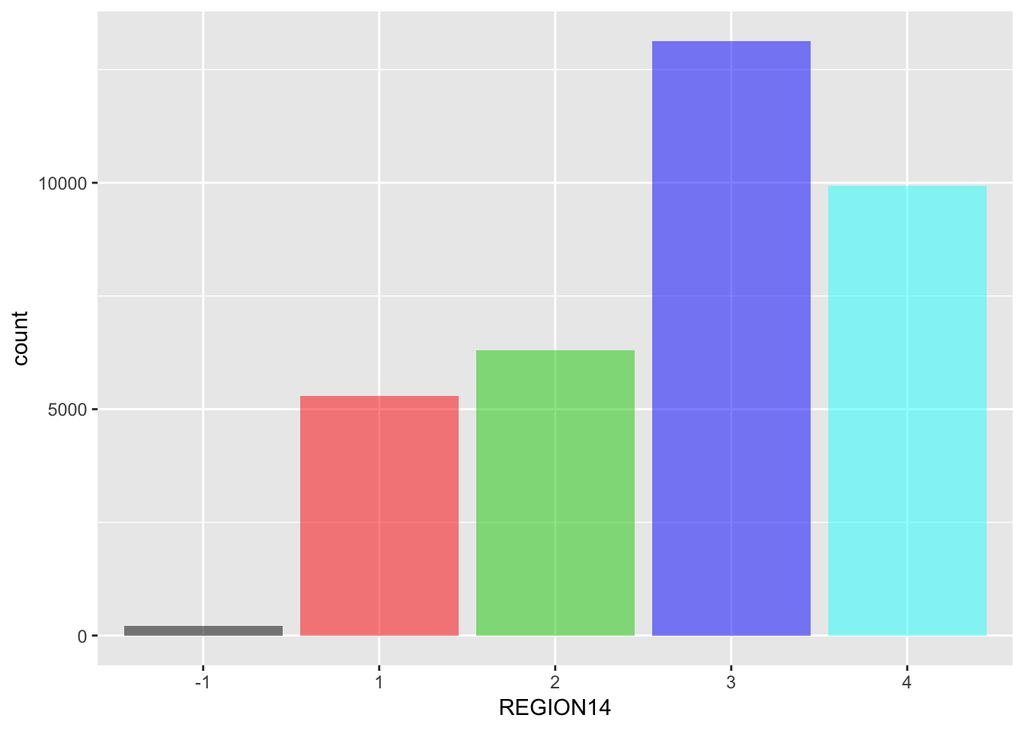

```r
#CHUNK 13
# Count summary
p1 <- ggplot(data = meps.sub, aes(x = REGION14)) +
  geom_bar(stat = "count", fill = c(1:5), alpha = 0.5)
p1
```

```r
# grid.arrange(p1,p2,p3,ncol=3)
```

Most are in regions 3 and 4.

#### Run CHUNK 14 to check for outliers in the age variable.

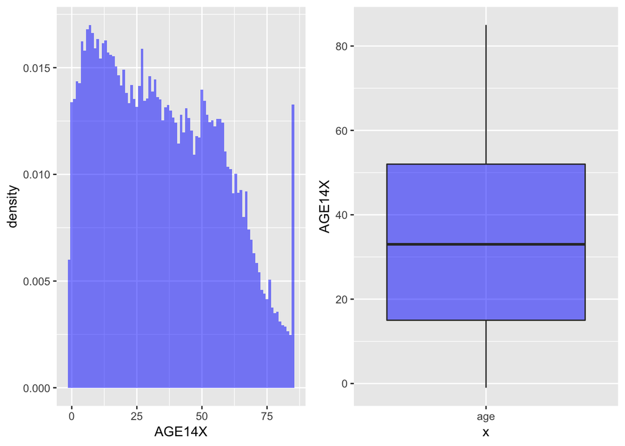

```r
#CHUNK 15
p1 <- ggplot(data = meps.sub, aes(AGE14X, ..density..)) +
       geom_histogram(binwidth = 1, fill = "blue", alpha = 0.5)
p2 <- ggplot(data = meps.sub, aes(x = "age", y = AGE14X)) +
        geom_boxplot(fill = "blue", alpha = 0.5)
grid.arrange(p1,p2,ncol=2)
```

There’s that bar all the way at the end again (high age). Though it didn’t seem to be flagged in the boxplot as an outlier.